# Data 605 - Final

Baron Curtin

2018-12-11

## Problem 1

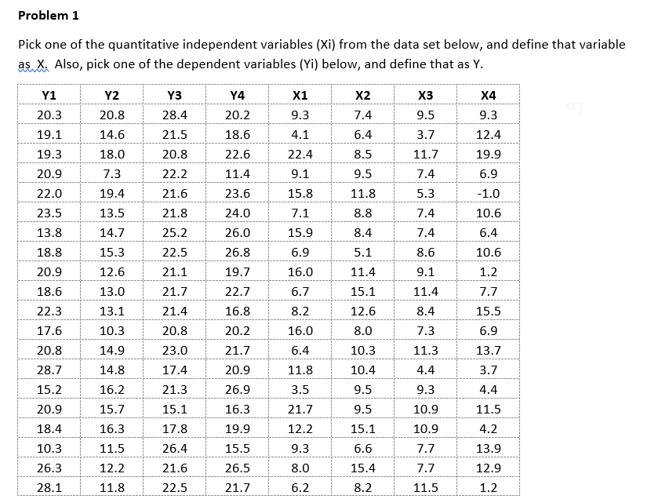

I chose to use X4 and Y4

### 1.1

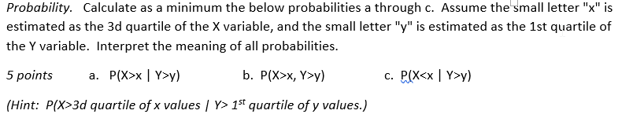

#### 1.1.a

$$P(X > x | Y > y) \\
\frac{P(X , Y)}{P(Y)}$$
The above reads as the probability that an X value is greater than the 3rd quartile of the X values given that the Y value is greater than the 1st quartile of the Y values

```
## [1] 0.2
```

This means that when Y values are greater than the 1st quartile of Y, there is a 20% chance that the X is greater than the 3rd quartile of X

#### 1.1.b

$P(X > x, Y > y)$

The above read as the probability that when X is greater than the 3rd quartile of X, Y is also greater than the 1st quartile of Y

```
## [1] 0.15
```

The probability of both of these events occuring is 15%

#### 1.1.c

$$P(X < x | Y > y) \\
\frac{P(X, Y)}{P(Y)}$$
The above reads as the probability that X is less than the 3rd quartile of X, given that Y is > than the 1st quartile of Y

```
## [1] 0.8
```

This means that there is an 80% probability that when Y is greater than the 1st quartile of Y, X is less than the 3rd quartile of X

I am adding the below just in case the probability was supposed to read less than or equal to $P(X \leq x | Y > y)$

```
## [1] 0.8
```

There is also an 80% chance of this occuring

### 1.2

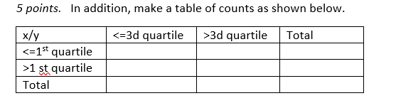

```
##     X/Y X<=x  X>x Total
## 1  Y<=y 0.15 0.10  0.25
## 2   Y>y 0.60 0.15  0.75
## 3 Total 0.75 0.25  1.00
```

### 1.3

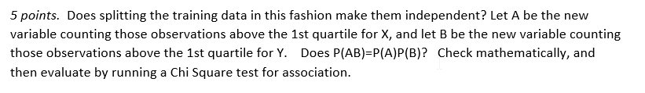

| PAB | PA_PB | Eq |
| --- | --- | --- |
| 0.75 | 0.5625 | FALSE |

```
##
##  Pearson's Chi-squared test with Yates' continuity correction
##
## data:  test
## X-squared = 0.8, df = 1, p-value = 0.3711
```

## Problem 2

### 2a

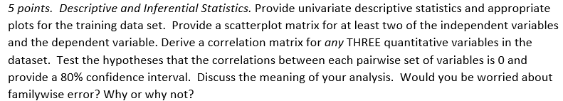

#### EDA

|  | Id | MSSubClass | LotFrontage | LotArea | OverallQual | OverallCond | YearBuilt | YearRemodAdd | MasVnrArea | BsmtFinSF1 | BsmtFinSF2 | BsmtUnfSF | TotalBsmtSF | X1stFlrSF | X2ndFlrSF | LowQualFinSF | GrLivArea | BsmtFullBath | BsmtHalfBath | FullBath | HalfBath | BedroomAbvGr | KitchenAbvGr | TotRmsAbvGrd | Fireplaces | GarageYrBlt | GarageCars | GarageArea | WoodDeckSF | … |
| --- | --- | --- | --- | --- | --- | --- | --- | --- | --- | --- | --- | --- | --- | --- | --- | --- | --- | --- | --- | --- | --- | --- | --- | --- | --- | --- | --- | --- | --- | --- |
| nobs | 1.460000e+03 | 1460.000000 | 1460.000000 | 1.460000e+03 | 1460.000000 | 1460.000000 | 1.460000e+03 | 1.460000e+03 | 1.460000e+03 | 1.460000e+03 | 1460.000000 | 1.460000e+03 | 1.460000e+03 | 1.460000e+03 | 1460.000000 | 1460.000000 | 1.460000e+03 | 1460.000000 | 1460.000000 | 1460.000000 | 1460.000000 | 1460.000000 | 1460.000000 | 1460.000000 | 1460.000000 | 1.460000e+03 | 1460.000000 | 1.460000e+03 | 1.460000e+03 | … |
| NAs | 0.000000e+00 | 0.000000 | 259.000000 | 0.000000e+00 | 0.000000 | 0.000000 | 0.000000e+00 | 0.000000e+00 | 8.000000e+00 | 0.000000e+00 | 0.000000 | 0.000000e+00 | 0.000000e+00 | 0.000000e+00 | 0.000000 | 0.000000 | 0.000000e+00 | 0.000000 | 0.000000 | 0.000000 | 0.000000 | 0.000000 | 0.000000 | 0.000000 | 0.000000 | 8.100000e+01 | 0.000000 | 0.000000e+00 | 0.000000e+00 | … |
| Minimum | 1.000000e+00 | 20.000000 | 21.000000 | 1.300000e+03 | 1.000000 | 1.000000 | 1.872000e+03 | 1.950000e+03 | 0.000000e+00 | 0.000000e+00 | 0.000000 | 0.000000e+00 | 0.000000e+00 | 3.340000e+02 | 0.000000 | 0.000000 | 3.340000e+02 | 0.000000 | 0.000000 | 0.000000 | 0.000000 | 0.000000 | 0.000000 | 2.000000 | 0.000000 | 1.900000e+03 | 0.000000 | 0.000000e+00 | 0.000000e+00 | … |
| Maximum | 1.460000e+03 | 190.000000 | 313.000000 | 2.152450e+05 | 10.000000 | 9.000000 | 2.010000e+03 | 2.010000e+03 | 1.600000e+03 | 5.644000e+03 | 1474.000000 | 2.336000e+03 | 6.110000e+03 | 4.692000e+03 | 2065.000000 | 572.000000 | 5.642000e+03 | 3.000000 | 2.000000 | 3.000000 | 2.000000 | 8.000000 | 3.000000 | 14.000000 | 3.000000 | 2.010000e+03 | 4.000000 | 1.418000e+03 | 8.570000e+02 | … |
| 1. Quartile | 3.657500e+02 | 20.000000 | 59.000000 | 7.553500e+03 | 5.000000 | 5.000000 | 1.954000e+03 | 1.967000e+03 | 0.000000e+00 | 0.000000e+00 | 0.000000 | 2.230000e+02 | 7.957500e+02 | 8.820000e+02 | 0.000000 | 0.000000 | 1.129500e+03 | 0.000000 | 0.000000 | 1.000000 | 0.000000 | 2.000000 | 1.000000 | 5.000000 | 0.000000 | 1.961000e+03 | 1.000000 | 3.345000e+02 | 0.000000e+00 | … |
| 3. Quartile | 1.095250e+03 | 70.000000 | 80.000000 | 1.160150e+04 | 7.000000 | 6.000000 | 2.000000e+03 | 2.004000e+03 | 1.660000e+02 | 7.122500e+02 | 0.000000 | 8.080000e+02 | 1.298250e+03 | 1.391250e+03 | 728.000000 | 0.000000 | 1.776750e+03 | 1.000000 | 0.000000 | 2.000000 | 1.000000 | 3.000000 | 1.000000 | 7.000000 | 1.000000 | 2.002000e+03 | 2.000000 | 5.760000e+02 | 1.680000e+02 | … |
| Mean | 7.305000e+02 | 56.897260 | 70.049958 | 1.051683e+04 | 6.099315 | 5.575342 | 1.971268e+03 | 1.984866e+03 | 1.036853e+02 | 4.436397e+02 | 46.549315 | 5.672404e+02 | 1.057429e+03 | 1.162627e+03 | 346.992466 | 5.844521 | 1.515464e+03 | 0.425342 | 0.057534 | 1.565068 | 0.382877 | 2.866438 | 1.046575 | 6.517808 | 0.613014 | 1.978506e+03 | 1.767123 | 4.729801e+02 | 9.424452e+01 | … |
| Median | 7.305000e+02 | 50.000000 | 69.000000 | 9.478500e+03 | 6.000000 | 5.000000 | 1.973000e+03 | 1.994000e+03 | 0.000000e+00 | 3.835000e+02 | 0.000000 | 4.775000e+02 | 9.915000e+02 | 1.087000e+03 | 0.000000 | 0.000000 | 1.464000e+03 | 0.000000 | 0.000000 | 2.000000 | 0.000000 | 3.000000 | 1.000000 | 6.000000 | 1.000000 | 1.980000e+03 | 2.000000 | 4.800000e+02 | 0.000000e+00 | … |
| Sum | 1.066530e+06 | 83070.000000 | 84130.000000 | 1.535457e+07 | 8905.000000 | 8140.000000 | 2.878051e+06 | 2.897904e+06 | 1.505510e+05 | 6.477140e+05 | 67962.000000 | 8.281710e+05 | 1.543847e+06 | 1.697435e+06 | 506609.000000 | 8533.000000 | 2.212577e+06 | 621.000000 | 84.000000 | 2285.000000 | 559.000000 | 4185.000000 | 1528.000000 | 9516.000000 | 895.000000 | 2.728360e+06 | 2580.000000 | 6.905510e+05 | 1.375970e+05 | … |
| SE Mean | 1.103404e+01 | 1.107057 | 0.700748 | 2.612216e+02 | 0.036195 | 0.029123 | 7.904460e-01 | 5.403150e-01 | 4.751756e+00 | 1.193663e+01 | 4.221918 | 1.156419e+01 | 1.148144e+01 | 1.011746e+01 | 11.424471 | 1.272524 | 1.375245e+01 | 0.013581 | 0.006248 | 0.014418 | 0.013161 | 0.021350 | 0.005767 | 0.042538 | 0.016872 | 6.648660e-01 | 0.019558 | 5.595528e+00 | 3.280266e+00 | … |

[output cut: 6 more lines]

#### Correlation

| predictor | SalePrice |
| --- | --- |
| SalePrice | 1.0000000 |
| OverallQual | 0.7978807 |
| GrLivArea | 0.7051536 |
| GarageCars | 0.6470336 |
| GarageArea | 0.6193296 |
| TotalBsmtSF | 0.6156122 |

| predictor | SalePrice |
| --- | --- |
| EnclosedPorch | -0.15484320 |
| KitchenAbvGr | -0.14049745 |
| OverallCond | -0.12439123 |
| MSSubClass | -0.08803170 |
| Id | -0.04712185 |
| BsmtHalfBath | -0.03651266 |

Most correlated variables - OverallQual, GrLivArea, GarageCars are the most highly correlated variables with SalePrice

#### Correlation Matrix

```
##             SalePrice OverallQual GrLivArea
## SalePrice   1.0000000   0.7909816 0.7086245
## OverallQual 0.7909816   1.0000000 0.5930074
## GrLivArea   0.7086245   0.5930074 1.0000000
```

#### Scatterplot Matrix

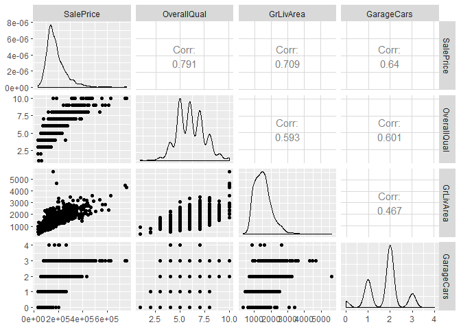

#### Hypothesis Test

##### GrLivArea & Saleprice

```
##
##  Pearson's product-moment correlation
##
## data:  train$GrLivArea and train$SalePrice
## t = 38.348, df = 1458, p-value < 2.2e-16
## alternative hypothesis: true correlation is not equal to 0
## 80 percent confidence interval:
##  0.6915087 0.7249450
## sample estimates:
##       cor
## 0.7086245
```

- The correlation between GrLivArea and SalePrice is not zero and the test shows the correlation to be ~.7086 and the p-value is very small showing statistical significance and thereby rejecting the null hypothesis
- The confidence interval for GrLivArea and SalePrice is ~.6915 - .7249

##### GarageCars & Saleprice

```
##
##  Pearson's product-moment correlation
##
## data:  train$GarageCars and train$SalePrice
## t = 31.839, df = 1458, p-value < 2.2e-16
## alternative hypothesis: true correlation is not equal to 0
## 80 percent confidence interval:
##  0.6201771 0.6597899
## sample estimates:
##       cor
## 0.6404092
```

- The correlation between GarageCars and SalePrice is not zero and the test shows the correlation to be ~.6404 and the p-value is very small showing statistical significance and thereby rejecting the null hypothesis
- The confidence interval for GarageCars and SalePrice is ~.6202 - .6598

##### OverallQual & Saleprice

```
##
##  Pearson's product-moment correlation
##
## data:  train$OverallQual and train$SalePrice
## t = 49.364, df = 1458, p-value < 2.2e-16
## alternative hypothesis: true correlation is not equal to 0
## 80 percent confidence interval:
##  0.7780752 0.8032204
## sample estimates:
##       cor
## 0.7909816
```

- The correlation between OverallQual and SalePrice is not zero and the test shows the correlation to be ~.7910 and the p-value is very small showing statistical significance and thereby rejecting the null hypothesis
- The confidence interval for OverallQual and SalePrice is ~.7781 - .8032

#### Family-Wise Error

```
## [1] 0.488
```

I am worried about a family-wise error given that the FWER is .488 very close to a 50% chance

### 2b

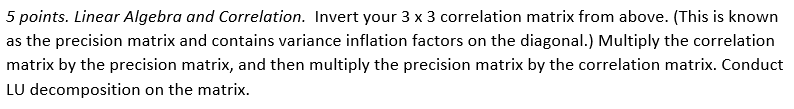

```
##             SalePrice OverallQual GrLivArea
## SalePrice   1.0000000   0.7909816 0.7086245
## OverallQual 0.7909816   1.0000000 0.5930074
## GrLivArea   0.7086245   0.5930074 1.0000000
```

[output not shown]

[output not shown]

#### LU Decomposition

```
## $L
##             SalePrice OverallQual GrLivArea
## SalePrice   1.0000000   0.0000000         0
## OverallQual 0.9409636   1.0000000         0
## GrLivArea   0.8865055  -0.3045399         1
##
## $U
##             SalePrice OverallQual  GrLivArea
## SalePrice    2.127801  2.00218278  1.8863069
## OverallQual  0.000000  0.09332866 -0.0284223
## GrLivArea    0.000000  0.00000000  0.1729292
```

### 2c

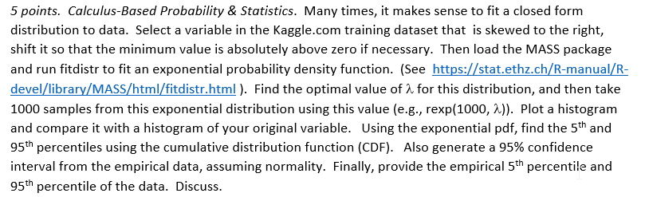

```
## [1] 1300
```

```
## [1] 1e-09
```

#### Fitdistr

```
##         rate
## 0.0001084972
```

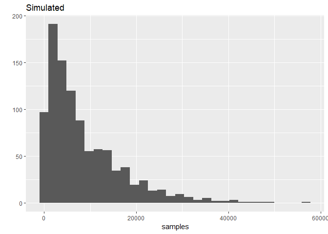

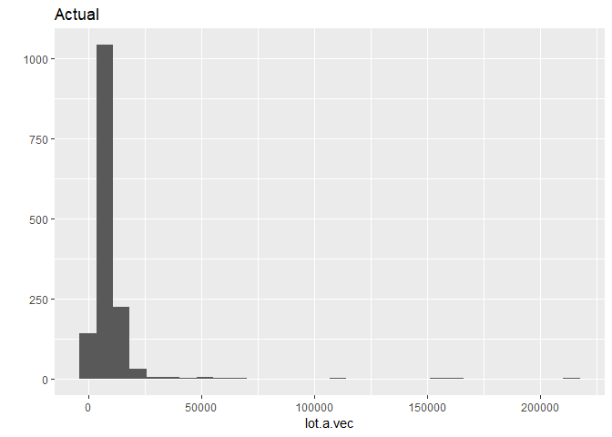

#### CDF 5, 95%

```
##     rate
## 472.7615
```

```
##     rate
## 27611.15
```

#### Empirical 5, 95%

```
##     5%
## 2011.7
```

```
##      95%
## 16101.15
```

#### Confidence Interval

```
## [1] 8704.418 9729.238
```

#### Summary Table

| name | p5 | p95 |
| --- | --- | --- |
| Sim | 472.7615 | 27611.149 |
| Emp | 2011.7000 | 16101.150 |
| CI | 8704.4180 | 9729.238 |

### 2d

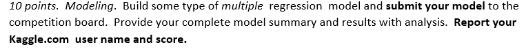

#### Clean Dataset

```
##   missForest iteration 1 in progress...done!
##   missForest iteration 2 in progress...done!
##   missForest iteration 3 in progress...done!
##   missForest iteration 1 in progress...done!
##   missForest iteration 2 in progress...done!
##   missForest iteration 3 in progress...done!
##   missForest iteration 4 in progress...done!
```

#### Regression Subsetting

```
## Reordering variables and trying again:
```

```
## Subset selection object
## Call: regsubsets.formula(SalePrice ~ ., data = newDfs[[1]], method = "exhaustive",
##     nvmax = NULL, nbest = 1, really.big = T)
## 36 Variables  (and intercept)
##               Forced in Forced out
## MSSubClass        FALSE      FALSE
## LotFrontage       FALSE      FALSE
## LotArea           FALSE      FALSE
## OverallQual       FALSE      FALSE
## OverallCond       FALSE      FALSE
## YearBuilt         FALSE      FALSE
## YearRemodAdd      FALSE      FALSE
## MasVnrArea        FALSE      FALSE
## BsmtFinSF1        FALSE      FALSE
## BsmtFinSF2        FALSE      FALSE
```

[output cut: 273 more lines]

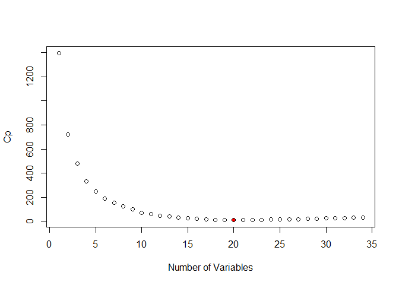

```
##   (Intercept)    MSSubClass   LotFrontage       LotArea   OverallQual
##          TRUE          TRUE          TRUE          TRUE          TRUE
##   OverallCond     YearBuilt  YearRemodAdd    MasVnrArea    BsmtFinSF1
##          TRUE          TRUE          TRUE          TRUE          TRUE
##    BsmtFinSF2     BsmtUnfSF   TotalBsmtSF    `1stFlrSF`    `2ndFlrSF`
##         FALSE         FALSE          TRUE         FALSE         FALSE
##  LowQualFinSF     GrLivArea  BsmtFullBath  BsmtHalfBath      FullBath
##         FALSE          TRUE          TRUE         FALSE          TRUE
##      HalfBath  BedroomAbvGr  KitchenAbvGr  TotRmsAbvGrd    Fireplaces
##         FALSE          TRUE          TRUE          TRUE          TRUE
##   GarageYrBlt    GarageCars    GarageArea    WoodDeckSF   OpenPorchSF
##         FALSE          TRUE         FALSE          TRUE         FALSE
## EnclosedPorch   `3SsnPorch`   ScreenPorch      PoolArea       MiscVal
##         FALSE         FALSE          TRUE         FALSE         FALSE
##        MoSold        YrSold
##         FALSE         FALSE
```

#### Model

```
##
## Call:
## lm(formula = SalePrice ~ MSSubClass + LotFrontage + LotArea +
##     OverallQual + OverallCond + YearBuilt + YearRemodAdd + MasVnrArea +
##     BsmtFinSF1 + TotalBsmtSF + GrLivArea + BsmtFullBath + FullBath +
##     BedroomAbvGr + KitchenAbvGr + TotRmsAbvGrd + Fireplaces +
##     GarageCars + WoodDeckSF + ScreenPorch, data = dfs[[1]])
##
## Residuals:
##     Min      1Q  Median      3Q     Max
## -469771  -17778   -2466   14317  294973
##
## Coefficients:
##                Estimate Std. Error t value Pr(>|t|)
## (Intercept)  -9.801e+05  1.412e+05  -6.941 6.42e-12 ***
## MSSubClass   -1.947e+02  3.110e+01  -6.261 5.35e-10 ***
## LotFrontage  -1.054e+02  5.682e+01  -1.855 0.063885 .
## LotArea       5.623e-01  1.537e-01   3.657 0.000266 ***
## OverallQual   1.760e+04  1.367e+03  12.873  < 2e-16 ***
## OverallCond   4.304e+03  1.209e+03   3.561 0.000384 ***
## YearBuilt     2.912e+02  6.114e+01   4.763 2.15e-06 ***
## YearRemodAdd  1.768e+02  7.528e+01   2.349 0.019012 *
## MasVnrArea    3.704e+01  6.782e+00   5.461 5.78e-08 ***
## BsmtFinSF1    1.046e+01  3.559e+00   2.939 0.003359 **
## TotalBsmtSF   7.376e+00  3.650e+00   2.021 0.043506 *
## GrLivArea     4.441e+01  4.861e+00   9.135  < 2e-16 ***
## BsmtFullBath  9.861e+03  2.785e+03   3.540 0.000416 ***
## FullBath      7.485e+03  2.988e+03   2.505 0.012371 *
## BedroomAbvGr -1.013e+04  1.926e+03  -5.258 1.73e-07 ***
## KitchenAbvGr -1.227e+04  5.538e+03  -2.215 0.026931 *
## TotRmsAbvGrd  5.263e+03  1.407e+03   3.740 0.000193 ***
## Fireplaces    4.683e+03  2.061e+03   2.273 0.023236 *
## GarageCars    1.139e+04  1.898e+03   6.003 2.58e-09 ***
## WoodDeckSF    2.405e+01  9.581e+00   2.510 0.012212 *
## ScreenPorch   5.403e+01  1.959e+01   2.758 0.005907 **
## ---
## Signif. codes:  0 '***' 0.001 '**' 0.01 '*' 0.05 '.' 0.1 ' ' 1
##
## Residual standard error: 36480 on 1174 degrees of freedom
##   (265 observations deleted due to missingness)
## Multiple R-squared:  0.8109, Adjusted R-squared:  0.8077
## F-statistic: 251.7 on 20 and 1174 DF,  p-value: < 2.2e-16
```

#### Evaluation

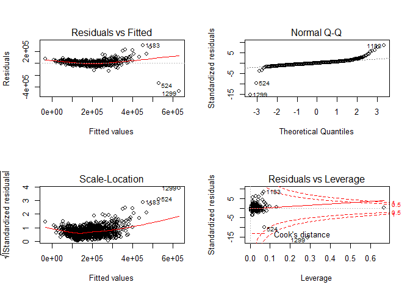

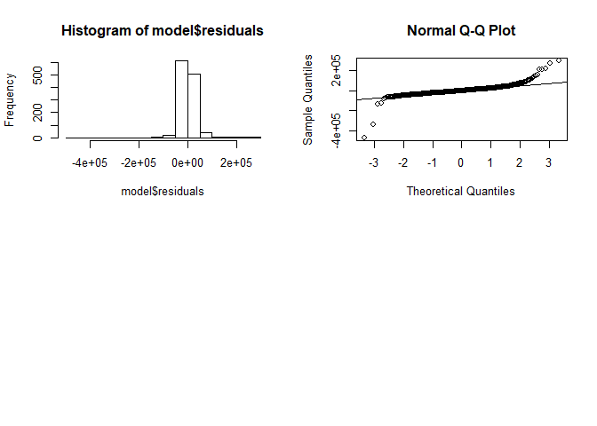

#### Predict

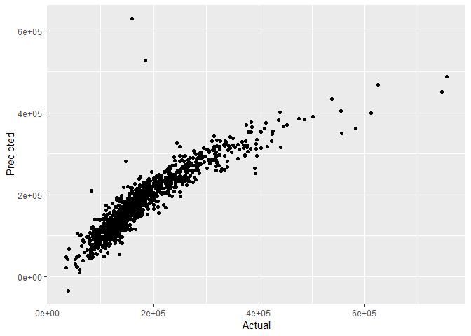

Overall, the model does a good job of predicting the SalePrice with the exception of a few outliers

#### Kaggle

Username: https://www.kaggle.com/baroncurtin2 Score: .24747

#### Youtube

https://youtu.be/5GBR9wOAdQE